# State Farm Distracted Drivers

Prev Exercises: Udacity:DeepLearning:TensorFlow:notMNIST

## Baseline

notMNIST: This notebook uses the [notMNIST](http://yaroslavvb.blogspot.com/2011/09/notmnist-dataset.html) dataset to be used with python experiments. This dataset is designed to look like the classic [MNIST](http://yann.lecun.com/exdb/mnist/) dataset, while looking a little more like real data: it's a harder task, and the data is a lot less 'clean' than MNIST.

```python
import pprint
import sys
print sys.version
```

```
2.7.11 (default, Jan 28 2016, 14:07:46)
[GCC 4.2.1 Compatible Apple LLVM 7.0.2 (clang-700.1.81)]
```

```python
# These are all the modules we'll be using later. Make sure you can import them
# before proceeding further.
import matplotlib.pyplot as plt
%matplotlib inline
import numpy as np
import os
import sys
import tarfile
from IPython.display import display, Image
from scipy import ndimage
from sklearn.linear_model import LogisticRegression
from six.moves.urllib.request import urlretrieve
from six.moves import cPickle as pickle
```

## Analytics Specs

#### This Project

```python
glbDataFile = {
            'url': 'https://www.kaggle.com/c/state-farm-distracted-driver-detection/download/',
         'filename': 'imgs.zip',
          'extract': False,
    'trnFoldersPth': 'imgs/train',
    'newFoldersPth': 'imgs/test'
    }

glbRspClass = ['c' + str(id) for id in xrange(10)]
glbRspClassN = len(glbRspClass)
glbImgSz = 32 # Pixel width and height.
glbImgPixelDepth = 255.0  # Number of levels per pixel.
glbImgColor = False

glbObsShuffleSeed = 127

glbPickleFile = 'img_import_data_SFDD_ImgSz_' + str(glbImgSz) + '.pickle'
```

```python
#print 'glbDataFile: %s' % (glbDataFile)
print 'glbRspClass: %s' % (glbRspClass)
print 'glbRspClassN: %d' % (glbRspClassN)
print 'glbPickleFile: %s' % (glbPickleFile)
```

```
glbRspClass: ['c0', 'c1', 'c2', 'c3', 'c4', 'c5', 'c6', 'c7', 'c8', 'c9']
glbRspClassN: 10
glbPickleFile: img_import_data_SFDD_ImgSz_32.pickle
```

#### notMNIST

```python
# glbDataURL = 'http://yaroslavvb.com/upload/notMNIST/'
# glbImgSz = 32
```

### Import Data

First, we'll download the dataset to our local machine.

```python
def maybe_download(url, filename, expected_bytes = None):
  """Download a file if not present, and make sure it's the right size."""
  if not os.path.exists('data/' + filename):
    filename, _ = urlretrieve(url + filename, filename)
  statinfo = os.stat('data/' + filename)
  verified = False
  if (expected_bytes == None):
    if (statinfo.st_size > 0):
        verified = True
  else:
    if (statinfo.st_size == expected_bytes):
        verified = True

  if verified:
    print('Found and verified', 'data/' + filename)
  else:
    raise Exception(
      'Failed to verify' + filename + '. Can you get to it with a browser?')
  return 'data/' + filename

dataFNm = maybe_download(glbDataFile['url'], glbDataFile['filename'])
```

```
('Found and verified', 'data/imgs.zip')
```

```python
# url = 'http://yaroslavvb.com/upload/notMNIST/'

# def maybe_download(url, filename, expected_bytes):
#   """Download a file if not present, and make sure it's the right size."""
#   if not os.path.exists(filename):
#     filename, _ = urlretrieve(url + filename, filename)
#   statinfo = os.stat(filename)
#   if statinfo.st_size == expected_bytes:
#     print('Found and verified', filename)
#   else:
#     raise Exception(
#       'Failed to verify' + filename + '. Can you get to it with a browser?')
#   return filename

# train_filename = maybe_download('data/notMNIST_large.tar.gz', 247336696)
# test_filename = maybe_download('data/notMNIST_small.tar.gz', 8458043)
```

Extract the dataset from the compressed downloaded file(s).

```python
def extract(filename, num_classes):
  print("Figure out automatically if data needs to be extracted")
  return

  tar = tarfile.open(filename)
  root = os.path.splitext(os.path.splitext(filename)[0])[0]  # remove .tar.gz
  print('Extracting data for %s. This may take a while. Please wait.' % root)
  sys.stdout.flush()
  tar.extractall()
  tar.close()
  # My edits: data_folders needs to be modified for the correct path
  data_folders = [
    os.path.join(root, d) for d in sorted(os.listdir(root)) if d != '.DS_Store']
  if len(data_folders) != num_classes:
    raise Exception(
      'Expected %d folders, one per class. Found %d instead.' % (
        num_classes, len(data_folders)))
  print(data_folders)
  return data_folders

if (glbDataFile['extract']):
    train_folders = extract(os.getcwd() + train_filename, glbRspClassN)
    test_folders  = extract(os.getcwd() + test_filename , glbRspClassN)
```

notMNINST:  
Extraction give you a set of directories, labelled A through J. The data consists of characters rendered in a variety of fonts on a 28x28 image. The labels are limited to 'A' through 'J' (10 classes). The training set has about 500k and the obsNewSet 19000 labelled examples. Given these sizes, it should be possible to train models quickly on any machine.

## Inspect data

Let's take a peek at some of the data to make sure it looks sensible.

```python
from IPython.display import display, Image
```

```
Class: c0
  img_88531.jpg:
```

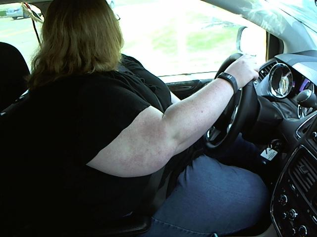

```
  img_58938.jpg:
```

[figure not shown]

```
  img_101286.jpg:
```

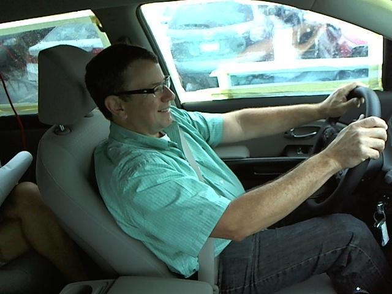

```
Class: c1
  img_15644.jpg:
```

[figure not shown]

```
  img_28295.jpg:
```

[figure not shown]

```
  img_34016.jpg:
```

[figure not shown]

```
Class: c2
  img_23445.jpg:
```

[figure not shown]

```
  img_100784.jpg:
```

[figure not shown]

```
  img_88495.jpg:
```

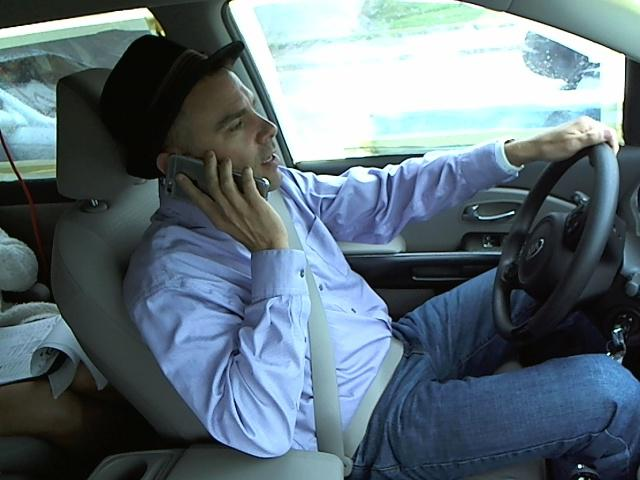

```
Class: c3
  img_53574.jpg:
```

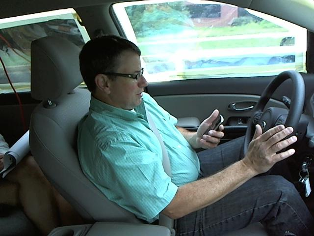

```
  img_58036.jpg:
```

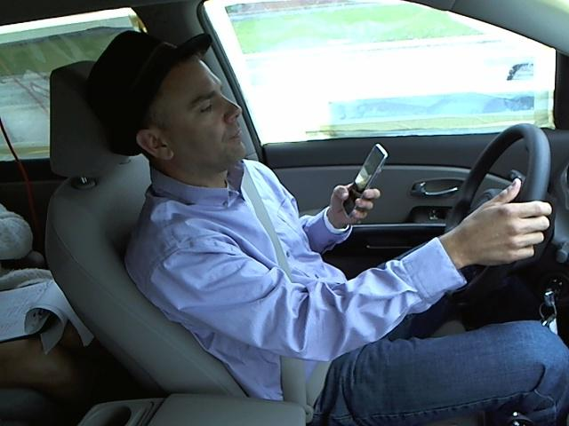

```
  img_31731.jpg:
```

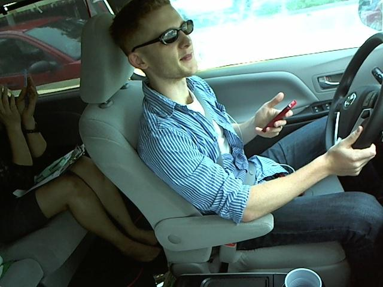

```
Class: c4
  img_37653.jpg:
```

[18 more figures not shown]

```python
# Display sample train images
trnFoldersPth = os.getcwd() + '/data/' + glbDataFile['trnFoldersPth']
newFoldersPth = os.getcwd() + '/data/' + glbDataFile['newFoldersPth']
# print(trnFoldersPth)
# print(newFoldersPth)

for cls in glbRspClass:
    print 'Class: %s' % (cls)
    clsPth = trnFoldersPth + '/' + cls
    onlyfiles = [f for f in os.listdir(clsPth) if os.path.isfile(os.path.join(clsPth, f))]
    for ix in np.random.randint(0, len(onlyfiles), size = 3):
        print '  %s:' % (onlyfiles[ix])
#         print '    no size spec:'
#         jpgfile = Image(clsPth + '/' + onlyfiles[ix], format = 'jpg')
#         display(jpgfile)
#         print '    glbImgSz:%d' % (glbImgSz)
        jpgfile = Image(clsPth + '/' + onlyfiles[ix], format = 'jpg',
                        width = glbImgSz * 4, height = glbImgSz * 4)
        display(jpgfile)
```

#### notMNINST:

Each exemplar should be an image of a character A through J rendered in a different font.

```python
# Display sample train images
# train_folders_path = '/Users/bbalaji-2012/Documents/Work/Courses/Udacity/DeepLearning/code/tensorflow/examples/udacity/data/notMNIST_large/'
# glbImgSz = 28
# display(Image(train_folders_path + 'A/a2F6b28udHRm.png', \
#               width = glbImgSz * 4, height = glbImgSz * 4))
# display(Image(train_folders_path + 'B/bnVuaS50dGY=.png', \
#               width = glbImgSz * 4, height = glbImgSz * 4))
# display(Image(train_folders_path + 'C/cmlzay50dGY=.png', \
#               width = glbImgSz * 4, height = glbImgSz * 4))
```

Now let's load the data in a more manageable format.

A few images might not be readable, we'll just skip them.

```python
trnFolders = os.getcwd() + '/data/' + glbDataFile['trnFoldersPth']
trnFolders = [trnFolders + '/' + cls for cls in glbRspClass]
print 'trnFolders: %s' % (trnFolders)
newFolders = [os.getcwd() + '/data/' + glbDataFile['newFoldersPth']]
print 'newFolders: %s' % (newFolders)
```

[output not shown]

```python
# data_folders_path = '/Users/bbalaji-2012/Documents/Work/Courses/Udacity/DeepLearning/code/tensorflow/examples/udacity/data/'
# train_folders = [data_folders_path + 'notMNIST_large/' + d \
#                  for d in sorted(os.listdir(data_folders_path + 'notMNIST_large/')) \
#                     if d != '.DS_Store']
# print train_folders
# test_folders  = [data_folders_path + 'notMNIST_small/' + d \
#                  for d in sorted(os.listdir(data_folders_path + 'notMNIST_small/')) \
#                     if d != '.DS_Store']
# print test_folders
```

```python
from scipy import misc as spmisc
```

```python
def load(data_folders, max_num_images, max_check = True):
  ids = ['' for ix in xrange(max_num_images)]
  dataset = np.ndarray(
    shape=(max_num_images, glbImgSz, glbImgSz), dtype=np.float32)
  labels = np.ndarray(shape=(max_num_images), dtype=np.int32)
  label_index = 0
  image_index = 0
  for folder in data_folders:
    print(folder)
    for image in os.listdir(folder):
      if max_check and (image_index >= max_num_images):
        raise Exception('More images than expected: %d >= %d' % (
          image_index, max_num_images))
      elif (image_index >= max_num_images):
        break

      image_file = os.path.join(folder, image)
      try:
        rsz_image_data = spmisc.imresize(ndimage.imread(image_file, flatten = not glbImgColor),
                                      (glbImgSz, glbImgSz))
        image_data = (rsz_image_data.astype(float) -
                      glbImgPixelDepth / 2) / glbImgPixelDepth
        if image_data.shape != (glbImgSz, glbImgSz):
          raise Exception('Unexpected image shape: %s' % str(image_data.shape))

        ids[image_index] = image
        dataset[image_index, :, :] = image_data
        labels[image_index] = label_index

        if  ((image_index >= 100000) and                            (image_index % 200000 == 0)) or \
            ((image_index >= 10000 ) and (image_index < 100000) and (image_index % 20000  == 0)) or \
            ((image_index >= 1000  ) and (image_index < 10000 ) and (image_index % 2000   == 0)) or \
            ((image_index >= 100   ) and (image_index < 1000  ) and (image_index % 200    == 0)) or \
            ((image_index >= 10    ) and (image_index < 100   ) and (image_index % 20     == 0)) or \
             (image_index ==  0    ) :
            print '  image_index: %d; %s:' % (image_index, image)
            display(spmisc.toimage(rsz_image_data))

        image_index += 1
      except IOError as e:
        print('Could not read:', image_file, ':', e, '- it\'s ok, skipping.')
    label_index += 1

  num_images = image_index
  ids = ids[0:num_images]
  dataset = dataset[0:num_images, :, :]
  labels = labels[0:num_images]
#   if num_images < min_num_images:
#     raise Exception('Many fewer images than expected: %d < %d' % (
#         num_images, min_num_images))
  print('Identifiers:', len(ids))
  print('Full dataset tensor:', dataset.shape)
  print('Mean:', np.mean(dataset))
  print('Standard deviation:', np.std(dataset))
  print('Labels:', labels.shape)
  return ids, dataset, labels

#smpObsTrnIdn, smpObsTrnFtr, smpObsTrnRsp = load(trnFolders, 250, max_check = False); print smpObsTrnIdn[10:15]
glbObsTrnIdn, glbObsTrnFtr, glbObsTrnRsp = load(trnFolders, 22435)
```

```
/Users/bbalaji-2012/Documents/Work/DataScience/Kaggle/StateFarm/data/imgs/train/c0
  image_index: 0; img_100026.jpg:
```

```
  image_index: 20; img_100828.jpg:
```

```
  image_index: 40; img_101613.jpg:
```

```
  image_index: 60; img_10514.jpg:
```

```
  image_index: 80; img_11035.jpg:
```

```
  image_index: 200; img_15760.jpg:
```

```
  image_index: 400; img_2334.jpg:
```

```
  image_index: 600; img_31424.jpg:
```

```
  image_index: 800; img_38288.jpg:
```

```
  image_index: 2000; img_81396.jpg:
```

```
/Users/bbalaji-2012/Documents/Work/DataScience/Kaggle/StateFarm/data/imgs/train/c1
  image_index: 4000; img_69700.jpg:
```

```
/Users/bbalaji-2012/Documents/Work/DataScience/Kaggle/StateFarm/data/imgs/train/c2
  image_index: 6000; img_5579.jpg:
```

```
/Users/bbalaji-2012/Documents/Work/DataScience/Kaggle/StateFarm/data/imgs/train/c3
  image_index: 8000; img_42902.jpg:
```

```
/Users/bbalaji-2012/Documents/Work/DataScience/Kaggle/StateFarm/data/imgs/train/c4
/Users/bbalaji-2012/Documents/Work/DataScience/Kaggle/StateFarm/data/imgs/train/c5
/Users/bbalaji-2012/Documents/Work/DataScience/Kaggle/StateFarm/data/imgs/train/c6
/Users/bbalaji-2012/Documents/Work/DataScience/Kaggle/StateFarm/data/imgs/train/c7
/Users/bbalaji-2012/Documents/Work/DataScience/Kaggle/StateFarm/data/imgs/train/c8
  image_index: 20000; img_86214.jpg:
```

```
/Users/bbalaji-2012/Documents/Work/DataScience/Kaggle/StateFarm/data/imgs/train/c9
('Identifiers:', 22424)
('Full dataset tensor:', (22424, 32, 32))
('Mean:', -0.14008653)
('Standard deviation:', 0.29186341)
('Labels:', (22424,))
```

```python
print glbObsTrnIdn[100:105]
glbObsNewIdn, glbObsNewFtr, glbObsNewRsp = load(newFolders, 79726)
```

```
['img_12203.jpg', 'img_12237.jpg', 'img_12238.jpg', 'img_12247.jpg', 'img_12279.jpg']
/Users/bbalaji-2012/Documents/Work/DataScience/Kaggle/StateFarm/data/imgs/test
  image_index: 0; img_1.jpg:
```

```
  image_index: 20; img_100017.jpg:
```

```
  image_index: 40; img_100040.jpg:
```

```
  image_index: 60; img_100066.jpg:
```

```
  image_index: 80; img_100086.jpg:
```

```
  image_index: 200; img_10022.jpg:
```

```
  image_index: 400; img_100459.jpg:
```

```
  image_index: 600; img_100684.jpg:
```

```
  image_index: 800; img_100910.jpg:
```

```
  image_index: 2000; img_10358.jpg:
```

```
  image_index: 4000; img_12655.jpg:
```

```
  image_index: 6000; img_14950.jpg:
```

```
  image_index: 8000; img_17241.jpg:
```

```
  image_index: 20000; img_31120.jpg:
```

```
  image_index: 40000; img_5424.jpg:
```

```
  image_index: 60000; img_77326.jpg:
```

```
('Identifiers:', 79726)
('Full dataset tensor:', (79726, 32, 32))
('Mean:', -0.13392374)
('Standard deviation:', 0.2979852)
('Labels:', (79726,))
```

```python
print glbObsNewIdn[1000:1005]
savObsNewRsp = glbObsNewRsp
glbObsNewRsp[:] = -1
print glbObsNewRsp[1000:1005]
```

```
['img_101147.jpg', 'img_101148.jpg', 'img_101149.jpg', 'img_10115.jpg', 'img_101150.jpg']
[-1 -1 -1 -1 -1]
```

```python
# def load(data_folders, min_num_images, max_num_images):
#   dataset = np.ndarray(
#     shape=(max_num_images, glbImgSz, glbImgSz), dtype=np.float32)
#   labels = np.ndarray(shape=(max_num_images), dtype=np.int32)
#   label_index = 0
#   image_index = 0
#   for folder in data_folders:
#     print(folder)
#     for image in os.listdir(folder):
#       if image_index >= max_num_images:
#         raise Exception('More images than expected: %d >= %d' % (
#           image_index, max_num_images))
#       image_file = os.path.join(folder, image)
#       try:
#         image_data = (ndimage.imread(image_file).astype(float) -
#                       glbImgPixelDepth / 2) / glbImgPixelDepth
#         if image_data.shape != (glbImgSz, glbImgSz):
#           raise Exception('Unexpected image shape: %s' % str(image_data.shape))
#         dataset[image_index, :, :] = image_data
#         labels[image_index] = label_index
#         image_index += 1
#       except IOError as e:
#         print('Could not read:', image_file, ':', e, '- it\'s ok, skipping.')
#     label_index += 1
#   num_images = image_index
#   dataset = dataset[0:num_images, :, :]
#   labels = labels[0:num_images]
#   if num_images < min_num_images:
#     raise Exception('Many fewer images than expected: %d < %d' % (
#         num_images, min_num_images))
#   print('Full dataset tensor:', dataset.shape)
#   print('Mean:', np.mean(dataset))
#   print('Standard deviation:', np.std(dataset))
#   print('Labels:', labels.shape)
#   return dataset, labels

# glbObsTrnFtr, glbObsTrnRsp = load(train_folders, 450000, 550000)
# glbObsNewFtr, glbObsNewRsp = load(test_folders, 18000, 20000)
```

We expect the data to be balanced across classes. Verify that.

```python
print 'glbObsTrnRsp class knts: '
print (np.unique(glbObsTrnRsp, return_counts = True))
print 'glbObsNewRsp class knts: '
print (np.unique(glbObsNewRsp, return_counts = True))
```

```
glbObsTrnRsp class knts:
(array([0, 1, 2, 3, 4, 5, 6, 7, 8, 9], dtype=int32), array([2489, 2267, 2317, 2346, 2326, 2312, 2325, 2002, 1911, 2129]))
glbObsNewRsp class knts:
(array([-1], dtype=int32), array([79726]))
```

```python
#print type(glbObsTrnRsp); print glbObsTrnRsp.shape; print glbObsTrnRsp[0:10]
# print np.sum(glbObsTrnRsp == 0)
# print np.unique(glbObsTrnRsp)
# print 'train labels freqs: %s' % \
#     ([np.sum(glbObsTrnRsp == thsLabel) for thsLabel in np.unique(glbObsTrnRsp)])
```

Save imported data.

```python
try:
  f = open('data/' + glbPickleFile, 'wb')
  save = {
    'glbObsTrnIdn': glbObsTrnIdn,
    'glbObsTrnFtr': glbObsTrnFtr,
    'glbObsTrnRsp': glbObsTrnRsp,
#     'glbObsVldFtr': glbObsVldFtr,
#     'glbObsVldRsp': glbObsVldRsp,
    'glbObsNewIdn': glbObsNewIdn,
    'glbObsNewFtr': glbObsNewFtr,
    'glbObsNewRsp': glbObsNewRsp,
    }
  pickle.dump(save, f, pickle.HIGHEST_PROTOCOL)
  f.close()
except Exception as e:
  print('Unable to save data to', glbPickleFile, ':', e)
  raise

statinfo = os.stat('data/' + glbPickleFile)
print('Compressed pickle size:', statinfo.st_size)
```

```
('Compressed pickle size:', 420848942)
```

```python
with open('data/' + glbPickleFile, 'rb') as f:
  save = pickle.load(f)
#   train_dataset = save['train_dataset']
#   train_labels = save['train_labels']
#   valid_dataset = save['valid_dataset']
#   valid_labels = save['valid_labels']
  glbObsNewIdn = save['glbObsNewIdn']
  glbObsNewFtr = save['glbObsNewFtr']
  glbObsNewRsp = save['glbObsNewRsp']
#   test_dataset = save['test_dataset']
#   test_labels = save['test_labels']
  del save  # hint to help gc free up memory
#   print('Training set', train_dataset.shape, train_labels.shape)
#   print('Validation set', valid_dataset.shape, valid_labels.shape)
  print('New set:', len(glbObsNewIdn), glbObsNewFtr.shape, glbObsNewRsp.shape)
```

```
('New set:', 79726, (79726, 32, 32), (79726,))
```

## Inspect Resized Image Data

Let's verify that the data still looks good. Displaying a sample of the labels and images from the ndarray.

```python
def mydisplayImages(obsIdn, obsFtr, obsRsp):
    imgIxLst = np.random.random_integers(0, obsFtr.shape[0] - 1, 10)
    for imgIx in imgIxLst:
        if (obsRsp[imgIx] > -1):
            print '  imgIx: %d; id: %s; label: %s' % \
                (imgIx, obsIdn[imgIx], glbRspClass[obsRsp[imgIx]])
        else:
            print '  imgIx: %d; id: %s; label: None' % (imgIx, obsIdn[imgIx])
        plt.figure
        plt.imshow(obsFtr[imgIx,:,:], cmap = plt.cm.gray)
        plt.show()
```

[output not shown]

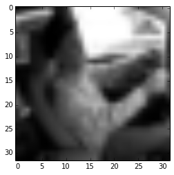

```
  imgIx: 16380; id: img_9998.jpg; label: c6
```

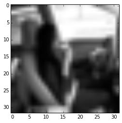

```
  imgIx: 12179; id: img_25277.jpg; label: c5
```

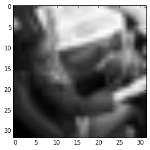

```
  imgIx: 20739; id: img_28025.jpg; label: c9
```

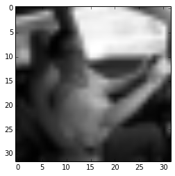

```
  imgIx: 16429; id: img_101869.jpg; label: c7
```

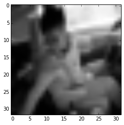

```
  imgIx: 13843; id: img_91231.jpg; label: c5
```

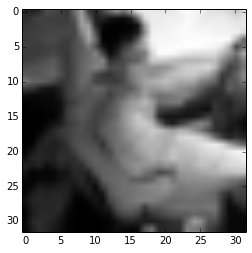

```
  imgIx: 11535; id: img_92193.jpg; label: c4
```

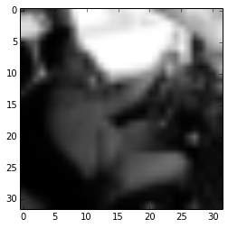

```
  imgIx: 18030; id: img_8399.jpg; label: c7
```

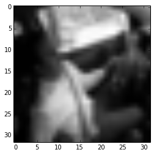

```
  imgIx: 10849; id: img_64316.jpg; label: c4
```

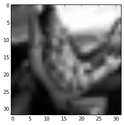

```
  imgIx: 16244; id: img_94378.jpg; label: c6
```

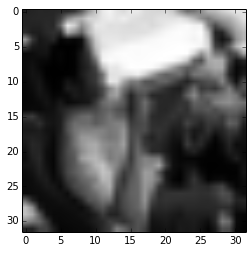

```python
print 'Trn set:'; mydisplayImages(glbObsTrnIdn, glbObsTrnFtr, glbObsTrnRsp)
```